# Challenge

You will need to use a model of your Zumo's behavior in order to be able to predict how far and fast it will go given different motor inputs for Project 1. We know that the Zumo's motors will be an important part of that model, so we need to develop some experience generating a dynamic model of an electric motor.

The challenge then is to develop this understanding by creating a validated model of your workstation motor using experimentally collected data that will allow you to predict the output for **any** step input. Since you are preparing to model the Zumo with different payloads, you will also need the model of the workstation motor to be able to handle physical changes in the system. For example, what if a "load" is added to the workstation motor? Therefore, you will need to develop a physics-based model that can account for these kinds of changes.

# *Model Development - Scoping:* Capturing a Step Input Response

We'll follow the the disciplined process from Week 03B and begin by identifying the inputs and outputs of the system. As you've already seen in your previous labs, the input to the motor is voltage and the output is angular velocity.

In order to scope the order of the differential equation we would use to model the system, we'll need to record the response of the motor's angular velocity to a step input in voltage. It will require a few steps to develop this experimental capability.

## Workstation Motor

An exploded view of the Pololu 50:1 gearmotor that will be used for the testing is shown below. **Find the motor windings, commutator and brushes on the diagram.**

*Consider revisting the material on DC motors from Lab 1 if these terms or concepts are not familiar to you.*

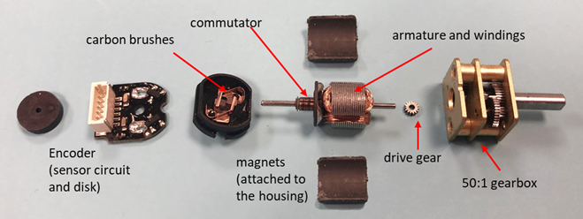

Relevant characteristics of the motor are provided by the [manufacturer](https://www.pololu.com/product/3073/specs).

**Your motor has a peak current of 1.5 amps (3 times the nomimal output of a typical USB connection) so the USB cable can't provide the power you need for this experiment. Use the power supply provided by your instructor and connect it to the workstation through the "5V power jack" labeled in the hardware resource: ME480 Portable Workstation**

## Measuring Motor Position

In order to measure the speed of the motor we will use the Pololu motor encoder that is attached to the back of the motor. The encoder can be used to measure both the position and speed of the motor. An image of our encoder is shown below. The disk has six embbeded magnetic poles (3 north, 3 south) that can be sensed by the Hall effect sensors attached to the small circuit board.

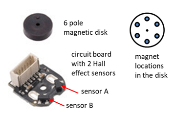

The encoder uses a method called quadrature to let us measure the incremental movement of the disk as well as its direction of rotation. The two Hall effect senors are 75° apart. That makes them 1.25 the distance between the magnets which are 60° apart. The animation below shows how this works with a wheel that has more magnets but with sensors separated by the same 1.25X the space between magnets. If you watch the animation you will see this positionging allows the system to measure position to 1/4 of the tick spacing and to sense the direction or rotation.

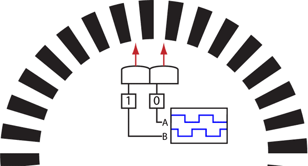

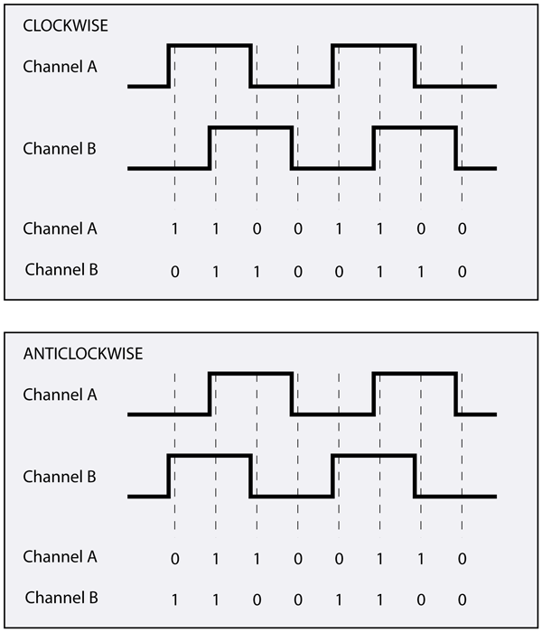

http://www.creative-robotics.com

If we track the number of transitions, we can measure the position of the motor from its starting point.

If we measure the time between transistions or we count the number of transitions over a fixed time, we can determine the speed of the motor. The hall-effect sensors and magnetic poles on the disk are arranged such that each sensor can measure 3 N-S or S-N transitions per revolution of the disk. This means that with a 51.45:1 gear ratio, a 3 pole-pair disk and quadrature we can measure to 1/3 x 1/4 x 1/51.45 of a rotation of the output shaft (0.00162*rotation or 0.6°).